# Data visualization

#### 5. Read ?facet_wrap. What does nrow do? What does ncol do? What other options control the layout of the individual panels? Why doesn’t facet_grid() have nrow and ncol arguments?

rnow= number of rows we want to use, and ncol gives the number of columns. However it is also a way of determining how do we want our graph to look like (see the next two example). Other control options inculde as.table, dir etc. as.table tells the control to plot the levels of the attribute as in the table. Its default is TRUE. While dir gives the direction of the plot when we use nrows. The default direction is horizontal.

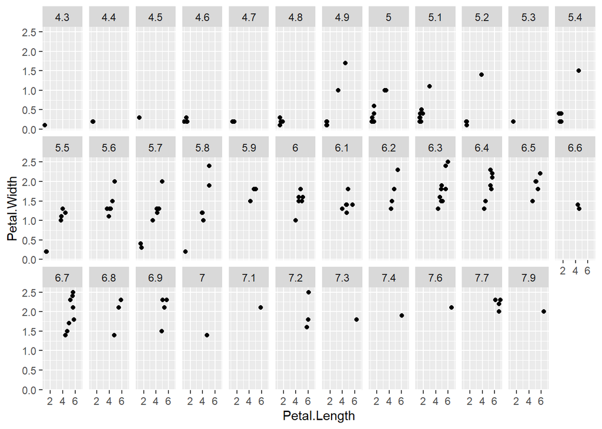

```r
ggplot(data=iris)+
  geom_point(mapping=aes(x=Petal.Length, y=Petal.Width ))+
  facet_wrap(~Sepal.Length, nrow=3)
```

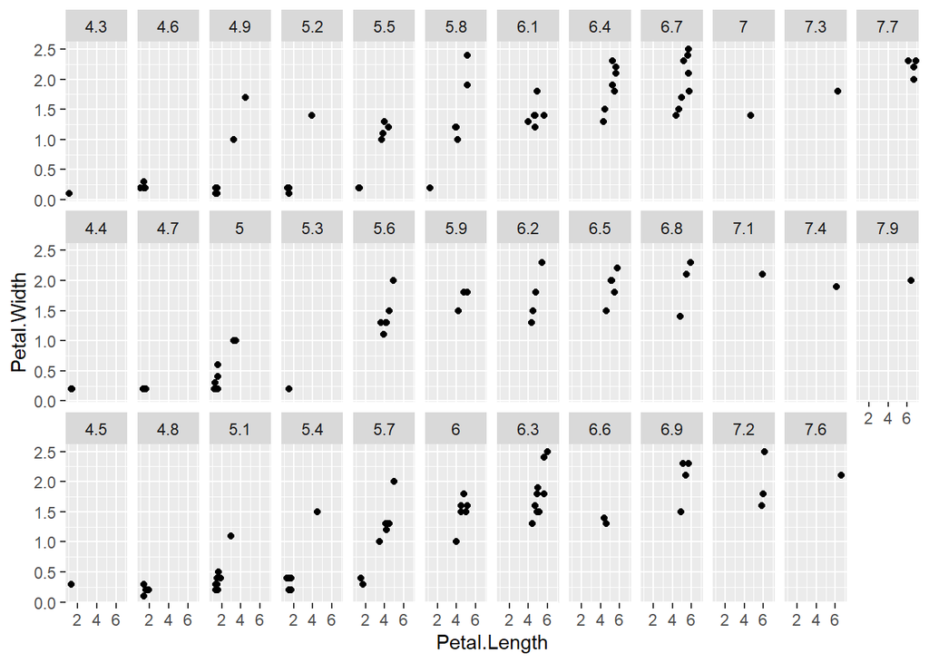

```r
ggplot(data=iris)+
  geom_point(mapping=aes(x=Petal.Length, y=Petal.Width ))+
  facet_wrap(~Sepal.Length, nrow=3, dir= "v") #same plot vertically directed
```

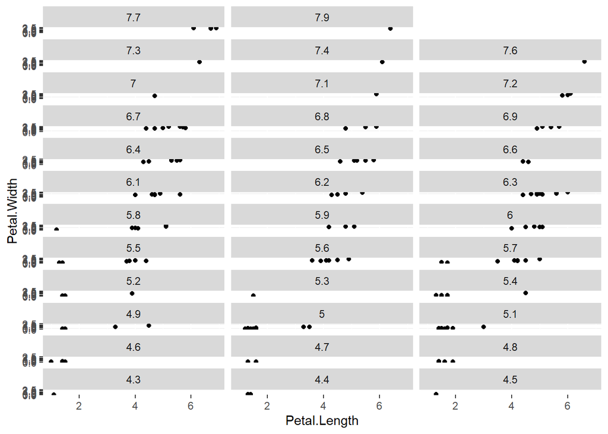

```r
ggplot(data=iris)+
  geom_point(mapping=aes(x=Petal.Length, y=Petal.Width ))+
  facet_wrap(~Sepal.Length, ncol=3, as.table = F) #as.table= F shows in the reverse order
```

#### 6. When using facet_grid() you should usually put the variable with more unique levels in the columns. Why?

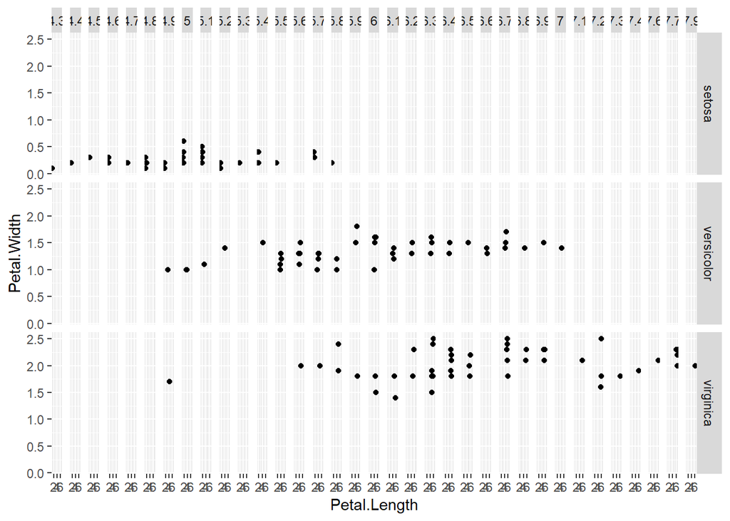

```r
ggplot(data=iris)+
  geom_point(mapping=aes(x=Petal.Length, y=Petal.Width ))+
  facet_grid(Species~Sepal.Length)
```

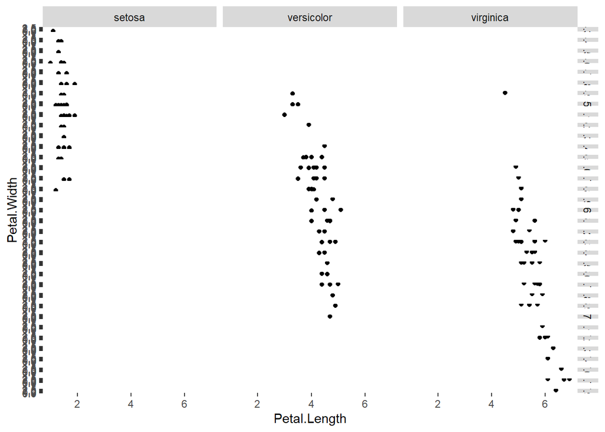

```r
ggplot(data=iris)+
  geom_point(mapping=aes(x=Petal.Length, y=Petal.Width ))+
  facet_grid(Sepal.Length~Species)
```

The two plots above shows that, the space for marking the columns is more than the space allocated for marking the rows. So if more levels are present in the crow attribute then it will be difficult to properly identify the points, and hence will cause interpretation error.

Find the next set of exercises in the next file.